# Wavelet Tensor Train as feature extractor

## Contents

- 1. Setting up
  - 1.1 Imports
  - 1.2 Configure parameters
  - 1.3 Custom functions
  - 1.4 Load data
- 2. Classification experiments
  - 2.1 Linear discriminant analysis
    - 2.1.1 Create grid of parameters
    - 2.1.2 Perform grid search
    - 2.1.3 Display best configurations depending on preprocessing parameters and original feature space of spectra
    - 2.1.4 Train-test accuracy plots for different combinations of (threshold, with_abs, with_mean, with_std)
    - 2.1.5 LDA perfomance for different ranks
  - 2.2 Logistic regression
    - 2.2.1 Create grid of parameters
    - 2.2.2 Perform grid search
    - 2.2.3 Display best configurations depending on preprocessing parameters and original feature space of spectra
    - 2.2.4 Train-test accuracy plots for different combinations of (threshold, with_abs, with_mean, with_std)
    - 2.2.5 LR perfomance for different ranks
- 3. Agglomerative clustering
  - 3.1 Create grid of parameters
  - 3.2 Perform grid search
  - 3.3 Display best configurations depending on preprocessing parameters and original feature space of spectra
  - 3.4 Mosaic plots of Adjusted Rand Index depending on best performing (in conditions of fixed subset of parameters) configurations
  - 3.5 AC perfomance for different ranks

## 1. Setting up

- 1.1 Imports
- 1.2 Configure parameters
- 1.3 Custom functions
- 1.4 Load data

Return to contents

### 1.1 Imports

Required packages are: [numpy](http://www.numpy.org/), [scipy](https://www.scipy.org/), [matplotlib](https://matplotlib.org/index.html), [seaborn](https://seaborn.pydata.org), [scikit-learn](http://scikit-learn.org/stable/index.html), [pywt](http://pywavelets.readthedocs.io/en/latest/), [pandas](https://pandas.pydata.org/), [statmodels](https://www.statsmodels.org/stable/index.html).

Up to section $\quad$ Return to contents

```python
import sys
sys.path.append('../src/')
import os
import re


import numpy as np

import pandas as pd
pd.set_option('display.max_columns', None)  # to show non-truncated version of table
pd.set_option('display.max_colwidth', -1)

import copy

from ml_classes import wttLDA
from ml_classes import wttLR
from ml_classes import wttAC
from ml_classes import wttSC

from nonlinearity import sign_thresh, hos_thresh

from alg_stats import get_gscv_stats
from alg_stats import GridSearchCV_unsupervised

import scipy.optimize

from files_io import ftirLoad

from sklearn.metrics import accuracy_score
from sklearn.metrics import fowlkes_mallows_score
from sklearn.metrics import adjusted_rand_score
from sklearn.metrics import adjusted_mutual_info_score

from sklearn.preprocessing import StandardScaler

from sklearn.cluster import SpectralClustering

from sklearn.model_selection import RepeatedStratifiedKFold
from sklearn.model_selection import GridSearchCV

from statsmodels.graphics.mosaicplot import mosaic

import matplotlib as mpl
mpl.use("pgf")
mpl.rcParams.update({
    "text.usetex": True,
    "pgf.texsystem": "xelatex",
    "pgf.preamble": [
        r'\usepackage{soul}',
    ]

})
import matplotlib.pyplot as plt
import seaborn as sns
from matplotlib.patches import Patch
from matplotlib.lines import Line2D

import matplotlib.cm as cm

%matplotlib inline
#%matplotlib notebook
```

### 1.2 Configure parameters

Up to section $\quad$ Return to contents

```python
# RepeatedKFoldCV configuration
n_splits = 4
n_repeats = 25

# number of parallel jobs for GridSearchCV
nJobsGSCV = 1

# limiter for FTIR spectrum (cm^{-1})
bandLim = 2000.

# random states for CV
random_state_cv_long = 235
random_state_cv_short = 578

# config for train-test plot
# Legend

colours_trte = cm.rainbow(np.linspace(0, 1, 8)) # abs/mean/std => 2^3
markers_trte = {
    'original': 'o',
    'd1': 's',
    'd2': '^'
}

legend_elements_trte = [
    Patch(
        facecolor=colours_trte[7],
        label=r'$\overline{\mathrm{abs}}$/$\overline{\mathrm{mean}}$/$\overline{\mathrm{std}}$'
    ),
    Patch(
        facecolor=colours_trte[6],
        label=r'$\overline{\mathrm{abs}}$/$\overline{\mathrm{mean}}$/std'
    ),
    Patch(
        facecolor=colours_trte[5],
        label=r'$\overline{\mathrm{abs}}$/mean/$\overline{\mathrm{std}}$'
    ),
    Patch(
        facecolor=colours_trte[4],
        label=r'$\overline{\mathrm{abs}}$/mean/std'
    ),
    Patch(
        facecolor=colours_trte[3],
        label=r'abs/$\overline{\mathrm{mean}}$/$\overline{\mathrm{std}}$'
    ),
    Patch(
        facecolor=colours_trte[2],
        label=r'abs/$\overline{\mathrm{mean}}$/std'
    ),
    Patch(
        facecolor=colours_trte[1],
        label=r'abs/mean/$\overline{\mathrm{std}}$'
    ),
    Patch(
        facecolor=colours_trte[0],
        label=r'abs/mean/std'
    ),

    Line2D(
        [0], [0], marker=markers_trte['original'], color='w', label=r'$f$',
        markerfacecolor='black', markersize=10
    ),
    Line2D(
        [0], [0], marker=markers_trte['d1'], color='w', label=r'$f^{\prime}$',
        markerfacecolor='black', markersize=10
    ),
    Line2D(
        [0], [0], marker=markers_trte['d2'], color='w', label=r'$f^{\prime\prime}$',
        markerfacecolor='black', markersize=10
    ),
]

barplot_palette = [
    '#CC3333', '#FF8C69', '#F2BC14', '#FFE8A0', '#046969', '#528B8B'
]
```

### 1.3 Custom functions

Up to section $\quad$ Return to contents

```python
def stringSplitByNumbers(x):
    '''
    from comment here
    http://code.activestate.com/recipes/135435-sort-a-string-using-numeric-order/
    '''
    r = re.compile('(\d+)')
    l = r.split(x)
    return [int(y) if y.isdigit() else y for y in l]

### Upsampling data to be of length 2^d
def upsample_data_degree2(data, freq):
    newN = int(2**np.floor(1+np.log2(data.shape[0])))
    newFreq = np.linspace(freq[0], freq[-1], newN)
    Y = []
    for k in xrange(Nsamples):
        finterp = scipy.interpolate.interp1d(freq, data[:, k], 'cubic')
        Y.append( finterp(newFreq) )
    newT = np.array(Y).T
    return newFreq, newT

def df2vec3(df, which='mean'):
    keys = df.columns.values

    param = df['params'].map(eval)
    keys = filter(lambda x: x.startswith('split'), keys)
    test_score_keys = filter(lambda x: x.endswith('test_score'), keys)
    test_score_keys = filter(lambda x: not (('mean' in x) or ('std' in x)), test_score_keys)
    test_score = df[test_score_keys].values #[df[key].values for key in test_score_keys]
    #test_score = np.vstack(test_score)
    train_score_keys = filter(lambda x: x.endswith('train_score'), keys)
    train_score_keys = filter(lambda x: not (('mean' in x) or ('std' in x)), train_score_keys)
    train_score = df[train_score_keys].values #[df[key].values for key in train_score_keys]
    #train_score = np.vstack(train_score)
    if which == 'mean':
        rv_train = np.mean(train_score, axis=1)
        rv_test = np.mean(test_score, axis=1)
    elif which == 'median':
        rv_train = np.median(train_score, axis=1)
        rv_test = np.median(test_score, axis=1)
    else:
        raise ValueError
    return rv_train, rv_test, param


def df2vec3_fromDirectory(dirname, filename_base, which='mean'):
    filenames = os.listdir(dirname)
    filenames = filter(lambda x: x.startswith(filename_base), filenames)
    filenames = sorted(filenames, key=stringSplitByNumbers)
    df_composed = []
    for i_fnm in xrange(len(filenames)):
        filename = filenames[i_fnm]
        df = pd.read_csv(dirname+filename)
        keys = df.columns.values
        #param = df['params']
        df.set_index('params', drop=True, append=False, inplace=True, verify_integrity=False)
        keys = filter(lambda x: (x.startswith('split')) or (x.endswith('train_score')), keys)
        df_composed.append( df[keys] )
    df_composed = pd.concat(df_composed, axis=1)
    df_composed['params'] = df.index
    return df2vec3(df_composed, which)

def get_indices_lda_wtt(
    gparams, th, with_abs, with_mean, with_std, rank=None):
    indices = map(
        lambda x: (
            (x['th'] == th) and
            (x['with_abs'] == with_abs) and
            (x['with_mean'] == with_mean) and
            (x['with_std'] == with_std)
        ),
        gparams
    )
    if rank is not None:
        indices2 = map(lambda x: x['rank'] == rank, gparams)
        indices = [indices[i] and indices2[i] for i in xrange(len(gparams))]
    return indices

def get_indices_lr_wtt(
    gparams, th, with_abs, with_mean, with_std,
    penalty=None, rank=None
):
    indices = map(
        lambda x: (
            (x['th'] == th) and
            (x['with_abs'] == with_abs) and
            (x['with_mean'] == with_mean) and
            (x['with_std'] == with_std)
        ),
        gparams
    )
    if rank is not None:
        indices2 = map(lambda x: x['rank'] == rank, gparams)
        indices = [indices[i] and indices2[i] for i in xrange(len(gparams))]
    return indices

def npz2vec3_fromDirectory(dirname, filename_base, ofs, which='mean'):
    filenames = os.listdir(dirname)
    filenames = filter(lambda x: x.startswith(filename_base+ofs), filenames)
    filenames = sorted(filenames, key=stringSplitByNumbers)
    df_composed = []
    axesList = None
    for i_fnm in xrange(len(filenames)):
        filename = filenames[i_fnm]
        df = np.load(dirname+filename)
        df_composed.append(df['res_wtt_'+ofs])
        if axesList is None:
            axesList = df['axes_wtt_'+ofs].tolist()
        else:
            assert axesList == df['axes_wtt_'+ofs].tolist()
    df_composed = np.concatenate(df_composed, axis=-3)
    if which == 'mean':
        df_composed = np.mean(df_composed, axis=-2) # eval
        df_composed = np.mean(df_composed, axis=-2) # cv
    elif which == 'median':
        df_composed = np.median(df_composed, axis=-2) # eval
        df_composed = np.median(df_composed, axis=-2) # cv
    else:
        raise NotImplementedError
    axesList = axesList[:-3]+axesList[-1:]
    return df_composed, axesList

def mosaicKeyMapper(x):
    if x in ('hard', 'soft'):
        return x
    return eval(x)

def custom_mosaic_wtt(mosaic_data, mosaic_data_3var_dict, cmapInstance):

    properties = lambda key: {'color': cmapInstance(mosaic_data[tuple(map(mosaicKeyMapper, key))])}
    fig, rect = mosaic(
        mosaic_data, gap=0.05, labelizer=lambda x: '',
        properties=properties
    )
    fig.set_size_inches(4, 3)
    fig.axes[0].set_xlabel('Standard scaling axis')
    fig.axes[2].set_xlabel('Subtract')
    fig.axes[1].set_ylabel('Threshold')
    fig.axes[1].yaxis.set_label_coords(1.05, 0.5)
    yticks = fig.axes[0].get_yticklabels()
    yticks = map(lambda x: mosaic_data_3var_dict[x.get_text()], yticks)
    fig.axes[0].set_yticklabels(yticks)
    return fig, rect
```

### 1.4 Load all necessary data

Up to section $\quad$ Return to contents

```python
data_dirname = '../data/'

## data with smaller resolution
fnms1 = [
    '08-07-2017-baselinecorrected.csv',
    '22-09-2017-baselinecorrected.csv'
]

## data with higher resolution
fnms2 = [
    '16-04-2018-baselinecorrected.csv',
    '18-04-2018-baselinecorrected.csv'
]

X1, labels1, freq = ftirLoad(fnms1, dirname=data_dirname)
X2, labels2, freq2 = ftirLoad(fnms2, dirname=data_dirname)

## v.2018 sampled more precisely; discretization points are exactly the same
X = np.hstack([X1[:-1, :], X2[::2, :]])
labels = labels1.tolist() + labels2.tolist()
labels = np.array(labels, dtype='i')
ind = np.where(freq <= bandLim)[0]
X, freq = X[ind], freq[ind]
Nsamples = X.shape[1]

# plain data for DWT
plainT = 0.01*X
# plain data for WTT (N=2^d)
freq2, plainT2 = upsample_data_degree2(plainT, freq)

# first order derivative data for DWT
dT = (plainT[2:] - plainT[:-2]) / (2.*np.reshape(freq[2:] - freq[:-2], [-1, 1]))
dFreq = freq[1:-1].copy()
# first order derivative data for WTT (N=2^d)
dFreq2, dT2 = upsample_data_degree2(dT, dFreq)

# second order derivative data for DWT
d2T = (plainT[2:] - 2*plainT[1:-1] + plainT[:-2]) / np.reshape(freq[2:] - freq[:-2], [-1, 1])**2.
d2Freq = freq[1:-1].copy()
# second order derivative data for WTT (N=2^d)
d2Freq2, d2T2 = upsample_data_degree2(d2T, d2Freq)

# generate CV indices
separator_long = RepeatedStratifiedKFold(
    n_splits=n_splits, n_repeats=n_repeats, random_state=random_state_cv_long
)
separator_short = RepeatedStratifiedKFold(
    n_splits=n_splits, n_repeats=1, random_state=random_state_cv_short
)

dummyX = np.empty(Nsamples)
train_indices_long, test_indices_long = [], []
for train_index, test_index in separator_long.split(dummyX, labels):
    train_indices_long.append(train_index)
    test_indices_long.append(test_index)

train_indices_short, test_indices_short = [], []
for train_index, test_index in separator_short.split(dummyX, labels):
    train_indices_short.append(train_index)
    test_indices_short.append(test_index)
custom_cv_short = zip(train_indices_short[:n_splits], test_indices_short[:n_splits])

del plainT, freq, dT, dFreq, d2T, d2Freq
```

```
63 (1869, 63)
17 (3736, 17)
```

## 2. Classification experiments

- 2.1 Linear discriminant analysis
  - 2.1.1 Create grid of parameters
  - 2.1.2 Perform grid search
  - 2.1.3 Display best configurations depending on preprocessing parameters and original feature space of spectra
  - 2.1.4 Train-test accuracy plots for different combinations of (threshold, with_abs, with_mean, with_std)
  - 2.1.5 LDA perfomance for different ranks
- 2.2 Logistic regression
  - 2.2.1 Create grid of parameters
  - 2.2.2 Perform grid search
  - 2.2.3 Display best configurations depending on preprocessing parameters and original feature space of spectra
  - 2.2.4 Train-test accuracy plots for different combinations of (threshold, with_abs, with_mean, with_std)
  - 2.2.5 LR perfomance for different ranks

Return to contents

### 2.1 Linear discriminant analysis

- 2.1.1 Create grid of parameters
- 2.1.2 Perform grid search
- 2.1.3 Display best configurations depending on preprocessing parameters and original feature space of spectra
- 2.1.4 Train-test accuracy plots for different combinations of (threshold, with_abs, with_mean, with_std)
- 2.1.5 LDA perfomance for different ranks

Up to section $\quad$ Return to contents

#### 2.1.1 Create grid of parameters

Up to subsection $\quad$ Up to section $\quad$ Return to contents

```python
filename_base = 'gscv_wtt_lda_'
results_dirname = '../results/wtt/lda/'
results_dirname_sign = '../results/wtt/lda_sign/'
if not os.path.isdir(results_dirname):
    os.makedirs(results_dirname)
if not os.path.isdir(results_dirname_sign):
    os.makedirs(results_dirname_sign)

dirnames = [results_dirname, results_dirname_sign]
nonlins = [hos_thresh, sign_thresh]
nonlin_names = ['hard/soft threshold', 'hard/soft threshold + signum']

param_grid = {}
param_grid['with_mean'] = [True, False]
param_grid['with_std'] = [True, False]
param_grid['with_abs'] = [True, False]
param_grid['th'] = ['soft', 'hard']
param_grid['tau'] = np.power(10., np.linspace(-5, 1, 10))
param_grid['rank'] = 1+np.arange(20)

Nranks = len(param_grid['rank'])
Ntau = len(param_grid['tau'])

parBool = [
    len(param_grid['th']),
    len(param_grid['with_abs']),
    len(param_grid['with_mean']),
    len(param_grid['with_std'])
]
loopParamNames = [
    'th',
    'with_abs',
    'with_mean',
    'with_std'
]
ntab = np.prod(parBool)
```

#### 2.1.2 Perform grid search

Up to subsection $\quad$ Up to section $\quad$ Return to contents

```python
for i in xrange(len(dirnames)):

    nonlin = nonlins[i]
    current_dirname = dirnames[i]

    print '============= %s ===========' % (nonlin_names[i])

    gscv_wtt_lda_plain = GridSearchCV(
        estimator=wttLDA(nonlin=nonlin), param_grid=param_grid, cv=custom_cv_short,
        n_jobs=nJobsGSCV, verbose=True,
        return_train_score=True, scoring='accuracy'
    )

    gscv_wtt_lda_d1 = GridSearchCV(
        estimator=wttLDA(nonlin=nonlin), param_grid=param_grid, cv=custom_cv_short,
        n_jobs=nJobsGSCV, verbose=True,
        return_train_score=True, scoring='accuracy'
    )

    gscv_wtt_lda_d2 = GridSearchCV(
        estimator=wttLDA(nonlin=nonlin), param_grid=param_grid, cv=custom_cv_short,
        n_jobs=nJobsGSCV, verbose=True,
        return_train_score=True, scoring='accuracy'
    )

    gscv_wtt_lda_plain.fit(plainT2.T, labels);
    # pandas 0.19 tries to make sorting of dict.keys()
    df_wtt_lda_plain = pd.DataFrame(gscv_wtt_lda_plain.cv_results_)
    df_wtt_lda_plain.to_csv(current_dirname+filename_base+'plain.csv', index=False)
    print 'Results are ready for plain data'
    gscv_wtt_lda_d1.fit(dT2.T, labels);
    # pandas 0.19 tries to make sorting of dict.keys()
    df_wtt_lda_d1 = pd.DataFrame(gscv_wtt_lda_d1.cv_results_)
    df_wtt_lda_d1.to_csv(current_dirname+filename_base+'d1.csv', index=False)
    print 'Results are ready for 1st derivative data'
    gscv_wtt_lda_d2.fit(d2T2.T, labels);
    # pandas 0.19 tries to make sorting of dict.keys()
    df_wtt_lda_d2 = pd.DataFrame(gscv_wtt_lda_d2.cv_results_)
    df_wtt_lda_d2.to_csv(current_dirname+filename_base+'d2.csv', index=False)
    print 'Results are ready for 2nd derivative data'
```

#### 2.1.3 Display best configurations depending on preprocessing parameters and original feature space of spectra

Up to subsection $\quad$ Up to section $\quad$ Return to contents

```python
for i_dnm in xrange(len(dirnames)):

    nonlin = nonlins[i_dnm]
    current_dirname = dirnames[i_dnm]

    print '============= %s ===========' % (nonlin_names[i_dnm])

    df_wtt_lda_plain = pd.read_csv(current_dirname+filename_base+'plain.csv')
    df_wtt_lda_d1 = pd.read_csv(current_dirname+filename_base+'d1.csv')
    df_wtt_lda_d2 = pd.read_csv(current_dirname+filename_base+'d2.csv')

    for k in xrange(ntab):
        index = np.unravel_index(k, parBool, order='C')
        current_param_values = [param_grid[loopParamNames[i]][index[i]] for i in xrange(len(loopParamNames))]
        th, with_abs, with_mean, with_std = current_param_values

        train_score, test_score, gparams = df2vec3(df_wtt_lda_plain)
        indices = get_indices_lda_wtt(gparams, th, with_abs, with_mean, with_std) #####################
        train_wtt_lda_plain, test_wtt_lda_plain = train_score[indices], test_score[indices]

        train_score, test_score, gparams = df2vec3(df_wtt_lda_d1)
        indices = get_indices_lda_wtt(gparams, th, with_abs, with_mean, with_std) ############
        train_wtt_lda_d1, test_wtt_lda_d1 = train_score[indices], test_score[indices]

        train_score, test_score, gparams = df2vec3(df_wtt_lda_d2)
        indices = get_indices_lda_wtt(gparams, th, with_abs, with_mean, with_std) ###################
        train_wtt_lda_d2, test_wtt_lda_d2 = train_score[indices], test_score[indices]

        train_wtt_lda_plain = np.reshape(train_wtt_lda_plain, [Nranks, Ntau]) # C order
        test_wtt_lda_plain = np.reshape(test_wtt_lda_plain, [Nranks, Ntau]) # C order
        train_wtt_lda_d1 = np.reshape(train_wtt_lda_d1, [Nranks, Ntau]) # C order
        test_wtt_lda_d1 = np.reshape(test_wtt_lda_d1, [Nranks, Ntau]) # C order
        train_wtt_lda_d2 = np.reshape(train_wtt_lda_d2, [Nranks, Ntau]) # C order
        test_wtt_lda_d2 = np.reshape(test_wtt_lda_d2, [Nranks, Ntau]) # C order

        ind1 = np.where(test_wtt_lda_plain == test_wtt_lda_plain.max())
        ind1 = tuple(map(lambda x: x[0], ind1))
        ind2 = np.where(test_wtt_lda_d1 == test_wtt_lda_d1.max())
        ind2 = tuple(map(lambda x: x[0], ind2))
        ind3 = np.where(test_wtt_lda_d2 == test_wtt_lda_d2.max())
        ind3 = tuple(map(lambda x: x[0], ind3))

        df_out = {}
        df_out['train'] = {
            'original (rank=%d, tau=%.2e)' % (
                param_grid['rank'][ind1[0]],
                param_grid['tau'][ind1[1]]
            ): train_wtt_lda_plain[ind1],
            '1st deriv. (rank=%d, tau=%.2e)' % (
                param_grid['rank'][ind2[0]],
                param_grid['tau'][ind2[1]]
            ): train_wtt_lda_d1[ind2],
            '2nd deriv. (rank=%d, tau=%.2e)' % (
                param_grid['rank'][ind3[0]],
                param_grid['tau'][ind3[1]]
            ): train_wtt_lda_d2[ind3],
        }
        df_out['test'] = {
            'original (rank=%d, tau=%.2e)' % (
                param_grid['rank'][ind1[0]],
                param_grid['tau'][ind1[1]]
            ): test_wtt_lda_plain[ind1],
            '1st deriv. (rank=%d, tau=%.2e)' % (
                param_grid['rank'][ind2[0]],
                param_grid['tau'][ind2[1]]
            ): test_wtt_lda_d1[ind2],
            '2nd deriv. (rank=%d, tau=%.2e)' % (
                param_grid['rank'][ind3[0]],
                param_grid['tau'][ind3[1]]
            ): test_wtt_lda_d2[ind3],
        }

        config_string = '%s thresholding; with_abs=%d, with_mean=%d, with_std=%d' % (
            th, with_abs, with_mean, with_std
        )
        df_out = pd.DataFrame(df_out)
        print config_string
        print df_out
        print
```

```
============= hard/soft threshold ===========
soft thresholding; with_abs=1, with_mean=1, with_std=1
                                       test     train
1st deriv. (rank=8, tau=1.00e-01)  0.670490  0.811641
2nd deriv. (rank=1, tau=1.00e-05)  0.601700  0.816098
original (rank=1, tau=4.64e-03)    0.382945  0.833172

soft thresholding; with_abs=1, with_mean=1, with_std=0
                                        test     train
1st deriv. (rank=5, tau=1.00e-05)   0.547409  0.916517
2nd deriv. (rank=18, tau=1.00e-05)  0.296107  0.541279
original (rank=1, tau=2.15e-04)     0.365766  0.912964

soft thresholding; with_abs=1, with_mean=0, with_std=1
                                       test     train
1st deriv. (rank=1, tau=2.15e-02)  0.815015  0.899492
2nd deriv. (rank=3, tau=1.00e-01)  0.747033  0.891428
original (rank=1, tau=1.00e-05)    0.923930  0.979151

soft thresholding; with_abs=1, with_mean=0, with_std=0
                                       test     train
1st deriv. (rank=5, tau=1.00e-05)  0.646031  0.954190
2nd deriv. (rank=1, tau=1.00e-05)  0.385097  0.737264
original (rank=6, tau=1.00e-05)    0.797562  0.950294

soft thresholding; with_abs=0, with_mean=1, with_std=1
                                        test     train
1st deriv. (rank=17, tau=1.00e-05)  0.882073  0.958302
2nd deriv. (rank=6, tau=4.64e-03)   0.845235  0.945642
original (rank=1, tau=1.00e-03)     0.909820  0.974840

soft thresholding; with_abs=0, with_mean=1, with_std=0
                                        test     train
1st deriv. (rank=15, tau=1.00e-05)  0.577349  0.924236
2nd deriv. (rank=10, tau=1.00e-05)  0.320566  0.562071
original (rank=13, tau=1.00e-05)    0.796967  0.949952

soft thresholding; with_abs=0, with_mean=0, with_std=1
                                        test     train
1st deriv. (rank=16, tau=1.00e-05)  0.883683  0.966507
```

[output cut: 138 more lines]

```
1st deriv. (rank=7, tau=1.00e-05)   0.819694  0.832563
2nd deriv. (rank=16, tau=1.00e-05)  0.299503  0.528724
original (rank=4, tau=2.15e-04)     0.898510  0.941478

hard thresholding; with_abs=0, with_mean=0, with_std=1
                                        test     train
1st deriv. (rank=12, tau=1.00e-05)  0.853797  0.808148
2nd deriv. (rank=18, tau=1.00e-03)  0.793624  0.699897
original (rank=4, tau=1.00e-01)     0.862742  0.941890

hard thresholding; with_abs=0, with_mean=0, with_std=0
                                        test     train
1st deriv. (rank=16, tau=1.00e-05)  0.813878  0.874405
2nd deriv. (rank=19, tau=1.00e-05)  0.354603  0.573903
original (rank=2, tau=2.15e-04)     0.859941  0.962413
```

#### 2.1.4 Train-test accuracy plots for different combinations of (threshold, with_abs, with_mean, with_std)

Up to subsection $\quad$ Up to section $\quad$ Return to contents

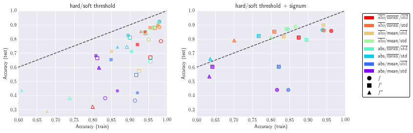

```python
f, ax = plt.subplots(1, 2, figsize=(12, 4))
sns.set_style('darkgrid')


for i_dnm in xrange(len(dirnames)):

    current_dirname = dirnames[i_dnm]

    df_wtt_lda_plain = pd.read_csv(current_dirname+filename_base+'plain.csv')
    df_wtt_lda_d1 = pd.read_csv(current_dirname+filename_base+'d1.csv')
    df_wtt_lda_d2 = pd.read_csv(current_dirname+filename_base+'d2.csv')




    for k in xrange(ntab):
        index = np.unravel_index(k, parBool, order='C')
        current_param_values = [param_grid[loopParamNames[i]][index[i]] for i in xrange(len(loopParamNames))]
        th, with_abs, with_mean, with_std = current_param_values

        train_score, test_score, gparams = df2vec3(df_wtt_lda_plain)
        indices = get_indices_lda_wtt(gparams, th, with_abs, with_mean, with_std) #####################
        train_wtt_lda_plain, test_wtt_lda_plain = train_score[indices], test_score[indices]

        train_score, test_score, gparams = df2vec3(df_wtt_lda_d1)
        indices = get_indices_lda_wtt(gparams, th, with_abs, with_mean, with_std) ############
        train_wtt_lda_d1, test_wtt_lda_d1 = train_score[indices], test_score[indices]

        train_score, test_score, gparams = df2vec3(df_wtt_lda_d2)
        indices = get_indices_lda_wtt(gparams, th, with_abs, with_mean, with_std) ###################
        train_wtt_lda_d2, test_wtt_lda_d2 = train_score[indices], test_score[indices]

        train_wtt_lda_plain = np.reshape(train_wtt_lda_plain, [Nranks, Ntau]) # C order
        test_wtt_lda_plain = np.reshape(test_wtt_lda_plain, [Nranks, Ntau]) # C order
        train_wtt_lda_d1 = np.reshape(train_wtt_lda_d1, [Nranks, Ntau]) # C order
        test_wtt_lda_d1 = np.reshape(test_wtt_lda_d1, [Nranks, Ntau]) # C order
        train_wtt_lda_d2 = np.reshape(train_wtt_lda_d2, [Nranks, Ntau]) # C order
        test_wtt_lda_d2 = np.reshape(test_wtt_lda_d2, [Nranks, Ntau]) # C order

        ind1 = np.where(test_wtt_lda_plain == test_wtt_lda_plain.max())
        ind1 = tuple(map(lambda x: x[0], ind1))
        ind2 = np.where(test_wtt_lda_d1 == test_wtt_lda_d1.max())
        ind2 = tuple(map(lambda x: x[0], ind2))
        ind3 = np.where(test_wtt_lda_d2 == test_wtt_lda_d2.max())
        ind3 = tuple(map(lambda x: x[0], ind3))

        colour_ind = k%8 # abs/mean/std
        if th == 'hard':
            ax[i_dnm].scatter(
                train_wtt_lda_plain[ind1], test_wtt_lda_plain[ind1], marker=markers_trte['original'],
                color=colours_trte[colour_ind], alpha=0.6,
                linewidth=0.5
            )

            ax[i_dnm].scatter(
                train_wtt_lda_d1[ind2], test_wtt_lda_d1[ind2], marker=markers_trte['d1'],
                color=colours_trte[colour_ind], alpha=0.6,
                linewidth=0.5
            )

            ax[i_dnm].scatter(
                train_wtt_lda_d2[ind3], test_wtt_lda_d2[ind3], marker=markers_trte['d2'],
                color=colours_trte[colour_ind], alpha=0.6,
                linewidth=0.5
            )
        else:

            ax[i_dnm].plot(
                train_wtt_lda_plain[ind1], test_wtt_lda_plain[ind1], marker=markers_trte['original'],
                alpha=0.9, markerfacecolor='None', markeredgewidth=1, markeredgecolor=colours_trte[colour_ind],
                linewidth=0.5, markersize=7
            )

            ax[i_dnm].plot(
                train_wtt_lda_d1[ind2], test_wtt_lda_d1[ind2], marker=markers_trte['d1'],
                alpha=0.9, markerfacecolor='None', markeredgewidth=1, markeredgecolor=colours_trte[colour_ind],
                linewidth=0.5, markersize=7
            )

            ax[i_dnm].plot(
                train_wtt_lda_d2[ind3], test_wtt_lda_d2[ind3], marker=markers_trte['d2'],
                alpha=0.9, markerfacecolor='None', markeredgewidth=1, markeredgecolor=colours_trte[colour_ind],
                linewidth=0.5, markersize=7
            )
        #break
    ax[i_dnm].set_xlim([0.6, 1.])
    ax[i_dnm].set_ylim([0.25, 1.])
    ax[i_dnm].set_xlabel('Accuracy (train)')
    ax[i_dnm].set_ylabel('Accuracy (test)')
    ax[i_dnm].plot([0., 1.], [0., 1.], ls="--", c=".3")
    ax[i_dnm].set_title(nonlin_names[i_dnm])

ax[i_dnm].legend(
    handles=legend_elements_trte, facecolor='white',
    edgecolor='black', fancybox=True, framealpha=1, frameon=True,
    ncol=1, bbox_to_anchor=(1.1, 1.)
)

plt.show()
```

#### 2.1.5 LDA perfomance for different ranks

Up to subsection $\quad$ Up to section $\quad$ Return to contents

```
current config: th=hard, with_abs=1, with_mean=0, with_std=1
```

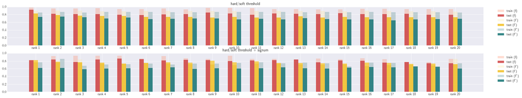

```python
th = 'hard'
with_abs = 1
with_mean = 0
with_std = 1

print 'current config: th=%s, with_abs=%d, with_mean=%d, with_std=%d' % (
    th, with_abs, with_mean, with_std
)

f, ax = plt.subplots(2, 1, figsize=(1.35*Nranks, 5))
barwidth = 0.2
x = np.arange(Nranks)

for i_dnm in xrange(len(dirnames)):

    current_dirname = dirnames[i_dnm]

    df_wtt_lda_plain = pd.read_csv(current_dirname+filename_base+'plain.csv')
    df_wtt_lda_d1 = pd.read_csv(current_dirname+filename_base+'d1.csv')
    df_wtt_lda_d2 = pd.read_csv(current_dirname+filename_base+'d2.csv')

    train_score, test_score, gparams = df2vec3(df_wtt_lda_plain)
    indices = get_indices_lda_wtt(
        gparams, th, with_abs, with_mean, with_std
    )
    train_wtt_lda_plain, test_wtt_lda_plain = train_score[indices], test_score[indices]

    train_score, test_score, gparams = df2vec3(df_wtt_lda_d1)
    indices = get_indices_lda_wtt(
        gparams, th, with_abs, with_mean, with_std
    )
    train_wtt_lda_d1, test_wtt_lda_d1 = train_score[indices], test_score[indices]

    train_score, test_score, gparams = df2vec3(df_wtt_lda_d2)
    indices = get_indices_lda_wtt(
        gparams, th, with_abs, with_mean, with_std
    )
    train_wtt_lda_d2, test_wtt_lda_d2 = train_score[indices], test_score[indices]

    train_wtt_lda_plain = np.reshape(train_wtt_lda_plain, [Nranks, Ntau]) # C order
    test_wtt_lda_plain = np.reshape(test_wtt_lda_plain, [Nranks, Ntau]) # C order
    train_wtt_lda_d1 = np.reshape(train_wtt_lda_d1, [Nranks, Ntau]) # C order
    test_wtt_lda_d1 = np.reshape(test_wtt_lda_d1, [Nranks, Ntau]) # C order
    train_wtt_lda_d2 = np.reshape(train_wtt_lda_d2, [Nranks, Ntau]) # C order
    test_wtt_lda_d2 = np.reshape(test_wtt_lda_d2, [Nranks, Ntau]) # C order

    ind = np.argmax(test_wtt_lda_plain, axis=1)

    acc_train = [train_wtt_lda_plain[i, ind[i]] for i in xrange(Nranks)]
    acc_test = [test_wtt_lda_plain[i, ind[i]] for i in xrange(Nranks)]
    acc_train = np.array(acc_train)
    acc_test = np.array(acc_test)

    b1a = ax[i_dnm].bar(
        x, acc_test, width=barwidth, color=barplot_palette[0], alpha=0.8
    )
    b2a = ax[i_dnm].bar(
        x, acc_train-acc_test, bottom=acc_test, width=barwidth, color=barplot_palette[1], alpha=0.3
    )

    ind = np.argmax(test_wtt_lda_d1, axis=1)

    acc_train = [train_wtt_lda_d1[i, ind[i]] for i in xrange(Nranks)]
    acc_test = [test_wtt_lda_d1[i, ind[i]] for i in xrange(Nranks)]
    acc_train = np.array(acc_train)
    acc_test = np.array(acc_test)

    b1b = ax[i_dnm].bar(
        x+barwidth, acc_test, width=barwidth, color=barplot_palette[2], alpha=0.8
    )
    b2b = ax[i_dnm].bar(
        x+barwidth, acc_train-acc_test, bottom=acc_test, width=barwidth, color=barplot_palette[3],
        alpha=0.3
    )

    ind = np.argmax(test_wtt_lda_d2, axis=1)

    acc_train = [train_wtt_lda_d2[i, ind[i]] for i in xrange(Nranks)]
    acc_test = [test_wtt_lda_d2[i, ind[i]] for i in xrange(Nranks)]
    acc_train = np.array(acc_train)
    acc_test = np.array(acc_test)

    b1c = ax[i_dnm].bar(
        x+2*barwidth, acc_test, width=barwidth, color=barplot_palette[4], alpha=0.8
    )
    b2c = ax[i_dnm].bar(
        x+2*barwidth, acc_train-acc_test, bottom=acc_test, width=barwidth, color=barplot_palette[5],
        alpha=0.3
    )

    #ind = np.unravel_index(ind, [Nmodes, Ntau], order='C')
    xticks = map(
        lambda x: 'rank '+str(x), param_grid['rank']
    )
    ax[i_dnm].set_ylim(0., 1.)
    ax[i_dnm].set_xticks(x+barwidth)
    ax[i_dnm].set_xticklabels(xticks)
    ax[i_dnm].legend(
        (b2a[0], b1a[0], b2b[0], b1b[0], b2c[0], b1c[0]),
        ('train (f)', 'test (f)', "train (f')", "test (f')", 'train (f")', 'test (f")'),
        loc='upper right',
        bbox_to_anchor=(1.08, 1.)
    )
    ax[i_dnm].yaxis.grid(True)
    ax[i_dnm].set_title(nonlin_names[i_dnm])
plt.show()
```

### 2.2 Logistic regression

- 2.2.1 Create grid of parameters
- 2.2.2 Perform grid search
- 2.2.3 Display best configurations depending on preprocessing parameters and original feature space of spectra
- 2.2.4 Train-test accuracy plots for different combinations of (threshold, with_abs, with_mean, with_std)
- 2.2.5 LR perfomance for different ranks

Up to section $\quad$ Return to contents

#### 2.2.1 Create grid of parameters

Up to subsection $\quad$ Up to section $\quad$ Return to contents

```python
filename_base = 'gscv_wtt_lr_'
results_dirname = '../results/wtt/lr/'
if not os.path.isdir(results_dirname):
    os.makedirs(results_dirname)

param_grid = {}
param_grid['C'] = np.power(10., np.arange(-5, 6))
param_grid['penalty'] = ['l1', 'l2']
param_grid['with_mean'] = [True, False]
param_grid['with_std'] = [True, False]
param_grid['with_abs'] = [True, False]
param_grid['th'] = ['soft', 'hard']
param_grid['tau'] = np.power(10., np.linspace(-5, 1, 10))
param_grid['rank'] = 1.+np.arange(20)

Nranks = len(param_grid['rank'])
Ntau = len(param_grid['tau'])
Nc = len(param_grid['C'])
Npenalty = len(param_grid['penalty'])

parBool = [
    len(param_grid['th']),
    len(param_grid['with_abs']),
    len(param_grid['with_mean']),
    len(param_grid['with_std'])
]

loopParamNames = [
    'th',
    'with_abs',
    'with_mean',
    'with_std'
]
ntab = np.prod(parBool)
```

#### 2.2.2 Perform grid search

Up to subsection $\quad$ Up to section $\quad$ Return to contents

```python
gscv_wtt_lr_plain = GridSearchCV(
    estimator=wttLR(solver='saga', multi_class='ovr', nonlin=sign_thresh),
    param_grid=param_grid, cv=custom_cv_short, n_jobs=nJobsGSCV, verbose=True,
    return_train_score=True, scoring='accuracy'
)

gscv_wtt_lr_d1 = GridSearchCV(
    estimator=wttLR(solver='saga', multi_class='ovr', nonlin=sign_thresh),
    param_grid=param_grid, cv=custom_cv_short, n_jobs=nJobsGSCV, verbose=True,
    return_train_score=True, scoring='accuracy'
)

gscv_wtt_lr_d2 = GridSearchCV(
    estimator=wttLR(solver='saga', multi_class='ovr', nonlin=sign_thresh),
    param_grid=param_grid, cv=custom_cv_short, n_jobs=nJobsGSCV, verbose=True,
    return_train_score=True, scoring='accuracy'
)

for k in xrange(len(custom_cv_short)):
    gscv_wtt_lr_plain = GridSearchCV(
        estimator=wttLR(solver='saga', multi_class='ovr', nonlin=sign_thresh),
        param_grid=param_grid, cv=custom_cv_short[k:k+1], n_jobs=nJobsGSCV, verbose=True,
        return_train_score=True, scoring='accuracy'
    )

    gscv_wtt_lr_d1 = GridSearchCV(
        estimator=wttLR(solver='saga', multi_class='ovr', nonlin=sign_thresh),
        param_grid=param_grid, cv=custom_cv_short[k:k+1], n_jobs=nJobsGSCV, verbose=True,
        return_train_score=True, scoring='accuracy'
    )

    gscv_wtt_lr_d2 = GridSearchCV(
        estimator=wttLR(solver='saga', multi_class='ovr', nonlin=sign_thresh),
        param_grid=param_grid, cv=custom_cv_short[k:k+1], n_jobs=nJobsGSCV, verbose=True,
        return_train_score=True, scoring='accuracy'
    )

    gscv_wtt_lr_plain.fit(plainT2.T, labels);
    df_wtt_lr_plain = pd.DataFrame(gscv_wtt_lr_plain.cv_results_)
    df_wtt_lr_plain.to_csv(results_dirname+filename_base+'plain_%d.csv' % (k), index=False)
    print 'Results are ready for plain data'

    gscv_wtt_lr_d1.fit(dT2.T, labels);
    df_wtt_lr_d1 = pd.DataFrame(gscv_wtt_lr_d1.cv_results_)
    df_wtt_lr_d1.to_csv(results_dirname+filename_base+'d1_%d.csv' % (k), index=False)
    print 'Results are ready for 1st derivative data'
    gscv_wtt_lr_d2.fit(d2T2.T, labels);
    df_wtt_lr_d2 = pd.DataFrame(gscv_wtt_lr_d2.cv_results_)
    df_wtt_lr_d2.to_csv(results_dirname+filename_base+'d2_%d.csv' % (k), index=False)
    print 'Results are ready for 2nd derivative data'
```

#### 2.2.3 Display best configurations depending on preprocessing parameters and original feature space of spectra

Up to subsection $\quad$ Up to section $\quad$ Return to contents

```python
for k in xrange(ntab):
    index = np.unravel_index(k, parBool, order='C')
    current_param_values = [param_grid[loopParamNames[i]][index[i]] for i in xrange(len(loopParamNames))]
    th, with_abs, with_mean, with_std = current_param_values

    train_score, test_score, gparams = df2vec3_fromDirectory(
        results_dirname, filename_base+'plain', which='mean'
    )
    indices = get_indices_lr_wtt(gparams, th, with_abs, with_mean, with_std)
    train_wtt_lr_plain, test_wtt_lr_plain = train_score[indices], test_score[indices]

    train_score, test_score, gparams = df2vec3_fromDirectory(
        results_dirname, filename_base+'d1', which='mean'
    )
    indices = get_indices_lr_wtt(gparams, th, with_abs, with_mean, with_std)
    train_wtt_lr_d1, test_wtt_lr_d1 = train_score[indices], test_score[indices]

    train_score, test_score, gparams = df2vec3_fromDirectory(
        results_dirname, filename_base+'d2', which='mean'
    )
    indices = get_indices_lr_wtt(gparams, th, with_abs, with_mean, with_std)
    train_wtt_lr_d2, test_wtt_lr_d2 = train_score[indices], test_score[indices]

    train_wtt_lr_plain = np.reshape(train_wtt_lr_plain, [Nc, Npenalty, Nranks, Ntau]) # C order
    test_wtt_lr_plain = np.reshape(test_wtt_lr_plain, [Nc, Npenalty, Nranks, Ntau]) # C order
    train_wtt_lr_d1 = np.reshape(train_wtt_lr_d1, [Nc, Npenalty, Nranks, Ntau]) # C order
    test_wtt_lr_d1 = np.reshape(test_wtt_lr_d1, [Nc, Npenalty, Nranks, Ntau]) # C order
    train_wtt_lr_d2 = np.reshape(train_wtt_lr_d2, [Nc, Npenalty, Nranks, Ntau]) # C order
    test_wtt_lr_d2 = np.reshape(test_wtt_lr_d2, [Nc, Npenalty, Nranks, Ntau]) # C order

    ind1 = np.where(test_wtt_lr_plain == test_wtt_lr_plain.max())
    ind1 = tuple(map(lambda x: x[0], ind1))
    ind2 = np.where(test_wtt_lr_d1 == test_wtt_lr_d1.max())
    ind2 = tuple(map(lambda x: x[0], ind2))
    ind3 = np.where(test_wtt_lr_d2 == test_wtt_lr_d2.max())
    ind3 = tuple(map(lambda x: x[0], ind3))

    df_out = {}
    df_out['train'] = {
        'original (%d [%s, C=%.1e, tau=%.2e])' % (
            param_grid['rank'][ind1[2]],
            param_grid['penalty'][ind1[1]],
            param_grid['C'][ind1[0]],
            param_grid['tau'][ind1[3]],
        ): train_wtt_lr_plain[ind1],
        '1st deriv. (%d [%s, C=%.1e, tau=%.2e])' % (
            param_grid['rank'][ind2[2]],
            param_grid['penalty'][ind2[1]],
            param_grid['C'][ind2[0]],
            param_grid['tau'][ind2[3]],
        ): train_wtt_lr_d1[ind2],
        '2nd deriv. (%d [%s, C=%.1e, tau=%.2e])' % (
            param_grid['rank'][ind3[2]],
            param_grid['penalty'][ind3[1]],
            param_grid['C'][ind3[0]],
            param_grid['tau'][ind3[3]],
        ): train_wtt_lr_d2[ind3],
    }
    df_out['test'] = {
        'original (%d [%s, C=%.1e, tau=%.2e])' % (
            param_grid['rank'][ind1[2]],
            param_grid['penalty'][ind1[1]],
            param_grid['C'][ind1[0]],
            param_grid['tau'][ind1[3]],
        ): test_wtt_lr_plain[ind1],
        '1st deriv. (%d [%s, C=%.1e, tau=%.2e])' % (
            param_grid['rank'][ind2[2]],
            param_grid['penalty'][ind2[1]],
            param_grid['C'][ind2[0]],
            param_grid['tau'][ind2[3]],
        ): test_wtt_lr_d1[ind2],
        '2nd deriv. (%d [%s, C=%.1e, tau=%.2e])' % (
            param_grid['rank'][ind3[2]],
            param_grid['penalty'][ind3[1]],
            param_grid['C'][ind3[0]],
            param_grid['tau'][ind3[3]],
        ): test_wtt_lr_d2[ind3],
    }
    config_string = '%s thresholding, with_abs=%d, with_mean=%d, with_std=%d' % (
        th, with_abs, with_mean, with_std
    )
    df_out = pd.DataFrame(df_out)
    print config_string
    print df_out
    print
```

```
soft thresholding, with_abs=1, with_mean=1, with_std=1
                                                   test  train
1st deriv. (2 [l1, C=1.0e+00, tau=1.00e-01])   0.873510  1.0
2nd deriv. (15 [l1, C=1.0e+00, tau=1.00e-01])  0.786131  1.0
original (3 [l1, C=1.0e+04, tau=1.00e-05])     0.574074  1.0

soft thresholding, with_abs=1, with_mean=1, with_std=0
                                                  test     train
1st deriv. (2 [l2, C=1.0e+00, tau=1.00e-05])  0.783397  1.000000
2nd deriv. (9 [l1, C=1.0e+01, tau=1.00e-05])  0.283066  0.458331
original (20 [l1, C=1.0e+02, tau=4.64e-05])   0.554622  1.000000

soft thresholding, with_abs=1, with_mean=0, with_std=1
                                                   test  train
1st deriv. (7 [l1, C=1.0e+00, tau=1.00e-05])   0.972794  1.0
2nd deriv. (15 [l1, C=1.0e+02, tau=1.00e-01])  0.888162  1.0
original (18 [l2, C=1.0e-01, tau=4.64e-03])    0.985294  1.0

soft thresholding, with_abs=1, with_mean=0, with_std=0
                                                  test     train
1st deriv. (3 [l1, C=1.0e+00, tau=1.00e-05])  0.888216  0.966562
2nd deriv. (9 [l2, C=1.0e+01, tau=1.00e-05])  0.369904  0.549895
original (7 [l2, C=1.0e-01, tau=1.00e-05])    0.985294  1.000000

soft thresholding, with_abs=0, with_mean=1, with_std=1
                                                   test  train
1st deriv. (20 [l2, C=1.0e+04, tau=4.64e-05])  0.985294  1.0
2nd deriv. (8 [l2, C=1.0e+00, tau=4.64e-01])   0.925121  1.0
original (16 [l2, C=1.0e+00, tau=1.00e-03])    0.973930  1.0

soft thresholding, with_abs=0, with_mean=1, with_std=0
                                                   test     train
1st deriv. (9 [l1, C=1.0e+01, tau=1.00e-05])   0.937621  1.000000
2nd deriv. (15 [l2, C=1.0e+01, tau=1.00e-05])  0.314209  0.536034
original (16 [l2, C=1.0e-01, tau=1.00e-05])    0.973389  1.000000

soft thresholding, with_abs=0, with_mean=0, with_std=1
                                                   test  train
1st deriv. (2 [l2, C=1.0e-01, tau=1.00e-01])   0.985294  1.0
2nd deriv. (13 [l1, C=1.0e+00, tau=2.15e-04])  0.962026  1.0
```

[output cut: 40 more lines]

```
1st deriv. (9 [l1, C=1.0e+01, tau=1.00e-05])   0.937621  1.000000
2nd deriv. (15 [l2, C=1.0e+01, tau=1.00e-05])  0.314209  0.536034
original (16 [l2, C=1.0e-01, tau=1.00e-05])    0.973389  1.000000

hard thresholding, with_abs=0, with_mean=0, with_std=1
                                                   test  train
1st deriv. (2 [l2, C=1.0e-01, tau=1.00e-01])   0.985294  1.0
2nd deriv. (13 [l1, C=1.0e+00, tau=1.00e-05])  0.962026  1.0
original (18 [l2, C=1.0e-01, tau=4.64e-03])    0.985294  1.0

hard thresholding, with_abs=0, with_mean=0, with_std=0
                                                   test     train
1st deriv. (10 [l1, C=1.0e+01, tau=1.00e-05])  0.949526  1.000000
2nd deriv. (18 [l2, C=1.0e+05, tau=1.00e-05])  0.355198  0.591053
original (7 [l2, C=1.0e-01, tau=1.00e-05])     0.985294  1.000000
```

#### 2.2.4 Train-test accuracy plots for different combinations of (threshold, with_abs, with_mean, with_std)

Up to subsection $\quad$ Up to section $\quad$ Return to contents

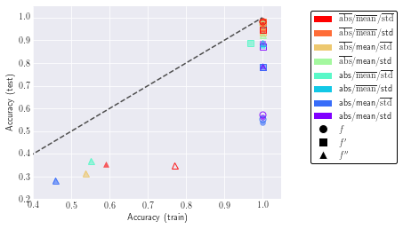

```python
f, ax = plt.subplots(1, 1, figsize=(5, 4))
sns.set_style('darkgrid')

for k in xrange(ntab):
    index = np.unravel_index(k, parBool, order='C')
    current_param_values = [param_grid[loopParamNames[i]][index[i]] for i in xrange(len(loopParamNames))]
    th, with_abs, with_mean, with_std = current_param_values

    train_score, test_score, gparams = df2vec3_fromDirectory(
        results_dirname, filename_base+'plain', which='mean'
    )
    indices = get_indices_lr_wtt(gparams, th, with_abs, with_mean, with_std)
    train_wtt_lr_plain, test_wtt_lr_plain = train_score[indices], test_score[indices]

    train_score, test_score, gparams = df2vec3_fromDirectory(
        results_dirname, filename_base+'d1', which='mean'
    )
    indices = get_indices_lr_wtt(gparams, th, with_abs, with_mean, with_std)
    train_wtt_lr_d1, test_wtt_lr_d1 = train_score[indices], test_score[indices]

    train_score, test_score, gparams = df2vec3_fromDirectory(
        results_dirname, filename_base+'d2', which='mean'
    )
    indices = get_indices_lr_wtt(gparams, th, with_abs, with_mean, with_std)
    train_wtt_lr_d2, test_wtt_lr_d2 = train_score[indices], test_score[indices]

    train_wtt_lr_plain = np.reshape(train_wtt_lr_plain, [Nc, Npenalty, Nranks, Ntau]) # C order
    test_wtt_lr_plain = np.reshape(test_wtt_lr_plain, [Nc, Npenalty, Nranks, Ntau]) # C order
    train_wtt_lr_d1 = np.reshape(train_wtt_lr_d1, [Nc, Npenalty, Nranks, Ntau]) # C order
    test_wtt_lr_d1 = np.reshape(test_wtt_lr_d1, [Nc, Npenalty, Nranks, Ntau]) # C order
    train_wtt_lr_d2 = np.reshape(train_wtt_lr_d2, [Nc, Npenalty, Nranks, Ntau]) # C order
    test_wtt_lr_d2 = np.reshape(test_wtt_lr_d2, [Nc, Npenalty, Nranks, Ntau]) # C order

    ind1 = np.where(test_wtt_lr_plain == test_wtt_lr_plain.max())
    ind1 = tuple(map(lambda x: x[0], ind1))
    ind2 = np.where(test_wtt_lr_d1 == test_wtt_lr_d1.max())
    ind2 = tuple(map(lambda x: x[0], ind2))
    ind3 = np.where(test_wtt_lr_d2 == test_wtt_lr_d2.max())
    ind3 = tuple(map(lambda x: x[0], ind3))

    ######################################################################################

    colour_ind = k%8 # abs/mean/std -> 2^3
    if th == 'hard':
        ax.scatter(
            train_wtt_lr_plain[ind1], test_wtt_lr_plain[ind1], marker=markers_trte['original'],
            color=colours_trte[colour_ind], alpha=0.6,
            linewidth=0.5
        )

        ax.scatter(
            train_wtt_lr_d1[ind2], test_wtt_lr_d1[ind2], marker=markers_trte['d1'],
            color=colours_trte[colour_ind], alpha=0.6,
            linewidth=0.5
        )

        ax.scatter(
            train_wtt_lr_d2[ind3], test_wtt_lr_d2[ind3], marker=markers_trte['d2'],
            color=colours_trte[colour_ind], alpha=0.6,
            linewidth=0.5
        )
    else:
        ax.plot(
            train_wtt_lr_plain[ind1], test_wtt_lr_plain[ind1], marker=markers_trte['original'],
            alpha=0.9, markerfacecolor='None', markeredgewidth=1, markeredgecolor=colours_trte[colour_ind],
            linewidth=0.5, markersize=7
        )

        ax.plot(
            train_wtt_lr_d1[ind2], test_wtt_lr_d1[ind2], marker=markers_trte['d1'],
            alpha=0.9, markerfacecolor='None', markeredgewidth=1, markeredgecolor=colours_trte[colour_ind],
            linewidth=0.5, markersize=7
        )

        ax.plot(
            train_wtt_lr_d2[ind3], test_wtt_lr_d2[ind3], marker=markers_trte['d2'],
            alpha=0.9, markerfacecolor='None', markeredgewidth=1, markeredgecolor=colours_trte[colour_ind],
            linewidth=0.5, markersize=7
        )
ax.set_xlim([0.4, 1.05])
ax.set_ylim([0.2, 1.05])
ax.set_xlabel('Accuracy (train)')
ax.set_ylabel('Accuracy (test)')
ax.plot([0., 1.], [0., 1.], ls="--", c=".3")
ax.legend(
    handles=legend_elements_trte, loc='best', facecolor='white',
    edgecolor='black', fancybox=True, framealpha=1, frameon=True,
    ncol=1, bbox_to_anchor=(1.1, 1.)
)
plt.show()
```

#### 2.2.5 LR perfomance for different ranks

Up to subsection $\quad$ Up to section $\quad$ Return to contents

```
current config: th=hard, with_abs=0, with_mean=0, with_std=1
```

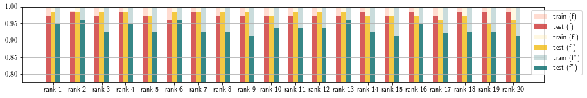

```python
th = 'hard'
with_abs = 0
with_mean = 0
with_std = 1

print 'current config: th=%s, with_abs=%d, with_mean=%d, with_std=%d' % (
    th, with_abs, with_mean, with_std
)

train_score, test_score, gparams = df2vec3_fromDirectory(
    results_dirname, filename_base+'plain', which='mean'
)
indices = get_indices_lr_wtt(gparams, th, with_abs, with_mean, with_std)
train_wtt_lr_plain, test_wtt_lr_plain = train_score[indices], test_score[indices]

train_score, test_score, gparams = df2vec3_fromDirectory(
    results_dirname, filename_base+'d1', which='mean'
)
indices = get_indices_lr_wtt(gparams, th, with_abs, with_mean, with_std)
train_wtt_lr_d1, test_wtt_lr_d1 = train_score[indices], test_score[indices]

train_score, test_score, gparams = df2vec3_fromDirectory(
    results_dirname, filename_base+'d2', which='mean'
)
indices = get_indices_lr_wtt(gparams, th, with_abs, with_mean, with_std)
train_wtt_lr_d2, test_wtt_lr_d2 = train_score[indices], test_score[indices]

train_wtt_all = np.stack([train_wtt_lr_plain, train_wtt_lr_d1, train_wtt_lr_d2], axis=0)
test_wtt_all = np.stack([test_wtt_lr_plain, test_wtt_lr_d1, test_wtt_lr_d2], axis=0)

train_wtt_all = np.reshape(train_wtt_all, [3, Nc, Npenalty, Nranks, Ntau]) # C order
test_wtt_all = np.reshape(test_wtt_all, [3, Nc, Npenalty, Nranks, Ntau]) # C order

train_wtt_all = np.transpose(train_wtt_all, [0, 1, 2, 4, 3])
test_wtt_all = np.transpose(test_wtt_all, [0, 1, 2, 4, 3])

train_wtt_all = np.reshape(train_wtt_all, [3, Nc*Npenalty*Ntau, Nranks], order='C')
test_wtt_all = np.reshape(test_wtt_all, [3, Nc*Npenalty*Ntau, Nranks], order='C')

ind1 = np.argmax(test_wtt_all[0], axis=0) # original signal as reference
ind2 = np.argmax(test_wtt_all[1], axis=0) # original signal as reference
ind3 = np.argmax(test_wtt_all[2], axis=0) # original signal as reference

f, ax = plt.subplots(figsize=(1.35*10, 2))
barwidth = 0.2

acc_train = [train_wtt_all[0, ind1[i], i] for i in xrange(len(param_grid['rank']))]
acc_test = [test_wtt_all[0, ind1[i], i] for i in xrange(len(param_grid['rank']))]
acc_train = np.array(acc_train)
acc_test = np.array(acc_test)

b1a = ax.bar(
    param_grid['rank'], acc_test, width=barwidth, color=barplot_palette[0], alpha=0.8
)
b2a = ax.bar(
    param_grid['rank'], acc_train-acc_test, bottom=acc_test, width=barwidth,
    color=barplot_palette[1], alpha=0.3
)

acc_train = [train_wtt_all[1, ind2[i], i] for i in xrange(len(param_grid['rank']))]
acc_test = [test_wtt_all[1, ind2[i], i] for i in xrange(len(param_grid['rank']))]
acc_train = np.array(acc_train)
acc_test = np.array(acc_test)

b1b = ax.bar(
    param_grid['rank']+barwidth, acc_test, width=barwidth, color=barplot_palette[2], alpha=0.8
)
b2b = ax.bar(
    param_grid['rank']+barwidth, acc_train-acc_test, bottom=acc_test, width=barwidth,
    color=barplot_palette[3], alpha=0.3
)

acc_train = [train_wtt_all[2, ind3[i], i] for i in xrange(len(param_grid['rank']))]
acc_test = [test_wtt_all[2, ind3[i], i] for i in xrange(len(param_grid['rank']))]
acc_train = np.array(acc_train)
acc_test = np.array(acc_test)

b1c = ax.bar(
    param_grid['rank']+2*barwidth, acc_test, width=barwidth, color=barplot_palette[4], alpha=0.8
)
b2c = ax.bar(
    param_grid['rank']+2*barwidth, acc_train-acc_test, bottom=acc_test, width=barwidth,
    color=barplot_palette[5], alpha=0.3
)

xticks = map(
    lambda x: 'rank %d' % (x), param_grid['rank']
)
ax.set_ylim(0.775, 1.)
ax.set_xticks(param_grid['rank']+barwidth)
ax.set_xticklabels(xticks)

ax.legend(
    (b2a[0], b1a[0], b2b[0], b1b[0], b2c[0], b1c[0]),
    ('train (f)', 'test (f)', "train (f')", "test (f')", 'train (f")', 'test (f")'),
    loc='upper right',
    bbox_to_anchor=(1.08, 1.)
)
ax.yaxis.grid(True)
plt.show()
```

## 3. Agglomerative lustering

- 3.1 Create grid of parameters
- 3.2 Perform grid search
- 3.3 Display best configurations depending on preprocessing parameters and original feature space of spectra
- 3.4 Mosaic plots of Adjusted Rand Index depending on best performing (in conditions of fixed subset of parameters) configurations
- 3.5 AC perfomance for different ranks

Return to contents

#### 3.1 Create grid of parameters

Up to section $\quad$ Return to contents

```python
param_grid = {}
param_grid['with_mean'] = [True, False]
param_grid['with_std'] = [True, False]
param_grid['with_abs'] = [True, False]
param_grid['stsc_axis'] = [0, 1]
param_grid['affinity'] = ['l1', 'l2', 'cosine', 'rbf']
param_grid['linkage'] = ['complete', 'average']

param_grid['subtract'] = [True, False]

param_grid['th'] = ['soft', 'hard']
param_grid['tau'] = np.power(10., np.linspace(-5, 1, 10))
param_grid['rank'] = 1+np.arange(20)

scoring = [
    adjusted_mutual_info_score,
    adjusted_rand_score,
    fowlkes_mallows_score
]

results_dirname = '../results/wtt/ac/'
if not os.path.isdir(results_dirname):
    os.makedirs(results_dirname)
filename_base = 'gscv_wtt_ac_'

n_clusters = len(np.unique(labels))
print 'Number of cluster: %d ' % (n_clusters)

parBool = [
    len(param_grid['stsc_axis']),
    len(param_grid['with_abs']),
    len(param_grid['with_mean']),
    len(param_grid['with_std']),
    len(param_grid['subtract']),
    len(param_grid['th'])
]

Naffinity = len(param_grid['affinity'])
Nlinkage = len(param_grid['linkage'])
Nranks = len(param_grid['rank'])
Ntau = len(param_grid['tau'])

loopParamNames = [
    'stsc_axis',
    'with_abs',
    'with_mean',
    'with_std',
    'subtract',
    'th'
]
ntab = np.prod(parBool)
scoringNames = [
    'Adjusted MI',
    'Adjusted Rand',
    'Fowlkes-Mallows'
]
ari_sn_i = scoringNames.index('Adjusted Rand')
```

```
Number of cluster: 7
```

#### 3.2 Perform grid search

Up to section $\quad$ Return to contents

```python
for k in xrange(len(custom_cv_short)):
    res_wtt_plain, axes_wtt_plain = GridSearchCV_unsupervised(
        estimator=wttAC(n_clusters=n_clusters, nonlin=hos_thresh), X=plainT2.T, y=labels, param_grid=param_grid,
        cv=train_indices_short[k:k+1], scoring=scoring, verbose=True, nEval=1
    )
    np.savez_compressed(
        results_dirname+filename_base+'plain_%d.npz' % (k),
        res_wtt_plain=res_wtt_plain,
        axes_wtt_plain=axes_wtt_plain
    )
    del res_wtt_plain, axes_wtt_plain
    print 'Results are ready for plain data'

    res_wtt_d1, axes_wtt_d1 = GridSearchCV_unsupervised(
        estimator=wttAC(n_clusters=n_clusters, nonlin=hos_thresh), X=dT2.T, y=labels, param_grid=param_grid,
        cv=train_indices_short[k:k+1], scoring=scoring, verbose=True, nEval=1
    )
    np.savez_compressed(
        results_dirname+filename_base+'d1_%d.npz' % (k),
        res_wtt_d1=res_wtt_d1,
        axes_wtt_d1=axes_wtt_d1
    )
    del res_wtt_d1, axes_wtt_d1
    print 'Results are ready for 1st derivative data'
    res_wtt_d2, axes_wtt_d2 = GridSearchCV_unsupervised(
        estimator=wttAC(n_clusters=n_clusters, nonlin=hos_thresh), X=d2T2.T, y=labels, param_grid=param_grid,
        cv=train_indices_short[k:k+1], scoring=scoring, verbose=True, nEval=1
    )
    np.savez_compressed(
        results_dirname+filename_base+'d2_%d.npz' % (k),
        res_wtt_d2=res_wtt_d2,
        axes_wtt_d2=axes_wtt_d2
    )
    print 'Results are ready for 2nd derivative data'
    del res_wtt_d2, axes_wtt_d2
```

#### 3.3 Display best configurations depending on preprocessing parameters and original feature space of spectra

Up to section $\quad$ Return to contents

```python
mosaic_data_ari_plain = {}
mosaic_data_ari_d1 = {}
mosaic_data_ari_d2 = {}
mosaic_data_3var_dict = {
    '7': r'$\overline{\mathrm{abs}}$/$\overline{\mathrm{mean}}$/$\overline{\mathrm{std}}$',
    '6': r'$\overline{\mathrm{abs}}$/$\overline{\mathrm{mean}}$/std',
    '5': r'$\overline{\mathrm{abs}}$/mean/$\overline{\mathrm{std}}$',
    '4': r'$\overline{\mathrm{abs}}$/mean/std',
    '3': r'abs/$\overline{\mathrm{mean}}$/$\overline{\mathrm{std}}$',
    '2': r'abs/$\overline{\mathrm{mean}}$/std',
    '1': r'abs/mean/$\overline{\mathrm{std}}$',
    '0': r'abs/mean/std'
}

objectiveScoreInd = ari_sn_i # Adjusted Rand

wtt_ac_plain, axesList_plain = npz2vec3_fromDirectory(
    results_dirname, filename_base, 'plain', which='mean'
)
wtt_ac_d1, axesList_d1 = npz2vec3_fromDirectory(
    results_dirname, filename_base, 'd1', which='mean'
)
wtt_ac_d2, axesList_d2 = npz2vec3_fromDirectory(
    results_dirname, filename_base, 'd2', which='mean'
)


for k in xrange(ntab):
    index = np.unravel_index(k, parBool, order='C')
    current_param_values = [param_grid[loopParamNames[i]][index[i]] for i in xrange(len(loopParamNames))]
    stsc_axis, with_abs, with_mean, with_std, subtract, th = current_param_values

    ind_plain = np.where(
        wtt_ac_plain[
            :, :, :, index[0], index[4], :, index[5], index[1], index[2], index[3], objectiveScoreInd
        ] == wtt_ac_plain[
            :, :, :, index[0], index[4], :, index[5], index[1], index[2], index[3], objectiveScoreInd
        ].max()
    )
    ind_d1 = np.where(
        wtt_ac_d1[
            :, :, :, index[0], index[4], :, index[5], index[1], index[2], index[3], objectiveScoreInd
        ] == wtt_ac_d1[
            :, :, :, index[0], index[4], :, index[5], index[1], index[2], index[3], objectiveScoreInd
        ].max()
    )
    ind_d2 = np.where(
        wtt_ac_d2[
            :, :, :, index[0], index[4], :, index[5], index[1], index[2], index[3], objectiveScoreInd
        ] == wtt_ac_d2[
            :, :, :, index[0], index[4], :, index[5], index[1], index[2], index[3], objectiveScoreInd
        ].max()
    )
    ind_plain = map(lambda x: x[0], ind_plain)
    ind_d1 = map(lambda x: x[0], ind_d1)
    ind_d2 = map(lambda x: x[0], ind_d2)

    scores_ac_plain = wtt_ac_plain[
        ind_plain[0], ind_plain[1], ind_plain[2],
        index[0], index[4],
        ind_plain[3],
        index[5], index[1], index[2], index[3], :
    ]
    scores_ac_d1 = wtt_ac_d1[
        ind_d1[0], ind_d1[1], ind_d1[2],
        index[0], index[4],
        ind_d1[3],
        index[5], index[1], index[2], index[3], :
    ]
    scores_ac_d2 = wtt_ac_d2[
        ind_d2[0], ind_d2[1], ind_d2[2],
        index[0], index[4],
        ind_d2[3],
        index[5], index[1], index[2], index[3], :
    ]

    mda_ind = (stsc_axis, (k/4)%8, subtract, th) # 2^3 - for abs/mean/std + 4 - for other two binary parameters

    mosaic_data_ari_plain[mda_ind] = scores_ac_plain[ari_sn_i]
    mosaic_data_ari_d1[mda_ind] = scores_ac_d1[ari_sn_i]
    mosaic_data_ari_d2[mda_ind] = scores_ac_d2[ari_sn_i]

    df_out = {}
    for i in xrange(len(scoringNames)):
        df_out[scoringNames[i]] = {}

        df_out[scoringNames[i]]['original (%s, %s, %s, %.2e): ' % (
            param_grid['affinity'][ind_plain[0]],
            param_grid['linkage'][ind_plain[1]],
            param_grid['rank'][ind_plain[2]],
            param_grid['tau'][ind_plain[3]]
        )] = scores_ac_plain[i]
        df_out[scoringNames[i]]['1st derivative (%s, %s, %s, %.2e): ' % (
            param_grid['affinity'][ind_d1[0]],
            param_grid['linkage'][ind_d1[1]],
            param_grid['rank'][ind_d1[2]],
            param_grid['tau'][ind_d1[3]]
        )] = scores_ac_d1[i]

        df_out[scoringNames[i]]['2nd derivative (%s, %s, %s, %.2e): ' % (
            param_grid['affinity'][ind_d2[0]],
            param_grid['linkage'][ind_d2[1]],
            param_grid['rank'][ind_d2[2]],
            param_grid['tau'][ind_d2[3]]
        )] = scores_ac_d2[i]
    config_string = 'stsc_axis=%d, with_abs=%d, with_mean=%d, with_std=%d, subtract=%d th=%s' % (
        stsc_axis, with_abs, with_mean, with_std, subtract, th
    )
    df_out = pd.DataFrame(df_out)

    print config_string
    print df_out
    print
```

```
stsc_axis=0, with_abs=1, with_mean=1, with_std=1, subtract=1 th=soft
                                                   Adjusted MI  Adjusted Rand  \
1st derivative (cosine, complete, 15, 2.15e+00):   0.356712     0.252678
2nd derivative (l2, complete, 18, 2.15e-02):       0.225659     0.147545
original (l2, complete, 16, 4.64e-01):             0.169296     0.127272

                                                   Fowlkes-Mallows
1st derivative (cosine, complete, 15, 2.15e+00):   0.386960
2nd derivative (l2, complete, 18, 2.15e-02):       0.300560
original (l2, complete, 16, 4.64e-01):             0.268144

stsc_axis=0, with_abs=1, with_mean=1, with_std=1, subtract=1 th=hard
                                                   Adjusted MI  Adjusted Rand  \
1st derivative (cosine, complete, 3, 1.00e-01):    0.310328     0.249068
2nd derivative (cosine, complete, 16, 2.15e+00):   0.201640     0.142737
original (cosine, complete, 1, 4.64e-01):          0.249535     0.173030

                                                   Fowlkes-Mallows
1st derivative (cosine, complete, 3, 1.00e-01):    0.359630
2nd derivative (cosine, complete, 16, 2.15e+00):   0.294570
original (cosine, complete, 1, 4.64e-01):          0.284994

stsc_axis=0, with_abs=1, with_mean=1, with_std=1, subtract=0 th=soft
                                                  Adjusted MI  Adjusted Rand  \
1st derivative (cosine, complete, 1, 1.00e-05):   0.194928     0.101699
2nd derivative (cosine, complete, 1, 1.00e-03):   0.160559     0.108056
original (cosine, complete, 1, 2.15e-02):         0.038355     0.027129

                                                  Fowlkes-Mallows
1st derivative (cosine, complete, 1, 1.00e-05):   0.319972
2nd derivative (cosine, complete, 1, 1.00e-03):   0.267061
original (cosine, complete, 1, 2.15e-02):         0.228199

stsc_axis=0, with_abs=1, with_mean=1, with_std=1, subtract=0 th=hard
                                                   Adjusted MI  Adjusted Rand  \
1st derivative (cosine, complete, 18, 1.00e-01):   0.212335     0.113695
2nd derivative (cosine, complete, 10, 1.00e-01):   0.160559     0.108056
original (cosine, complete, 1, 2.15e+00):          0.025202     0.029338

                                                   Fowlkes-Mallows
```

[output cut: 648 more lines]

```
                                                  Fowlkes-Mallows
1st derivative (cosine, complete, 3, 1.00e-05):   0.340163
2nd derivative (l1, complete, 9, 1.00e-05):       0.260875
original (cosine, complete, 18, 2.15e-04):        0.225519

stsc_axis=1, with_abs=0, with_mean=0, with_std=0, subtract=0 th=hard
                                                  Adjusted MI  Adjusted Rand  \
1st derivative (cosine, complete, 8, 1.00e-05):   0.346053     0.223915
2nd derivative (l1, average, 16, 1.00e-05):       0.103354     0.078813
original (cosine, complete, 11, 4.64e-03):        0.100159     0.067596

                                                  Fowlkes-Mallows
1st derivative (cosine, complete, 8, 1.00e-05):   0.388600
2nd derivative (l1, average, 16, 1.00e-05):       0.272403
original (cosine, complete, 11, 4.64e-03):        0.234057
```

#### 3.4 Mosaic plots of Adjusted Rand Index depending on best performing (in conditions of fixed subset of parameters) configurations

Up to section $\quad$ Return to contents

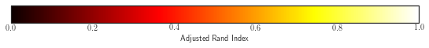

```
Original signal
```

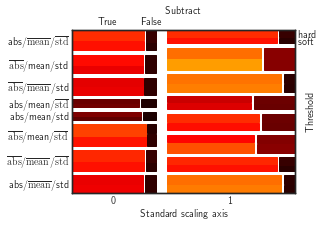

```
1st derivative
```

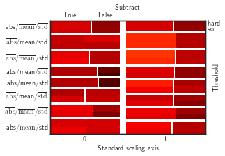

```
2nd derivative
```

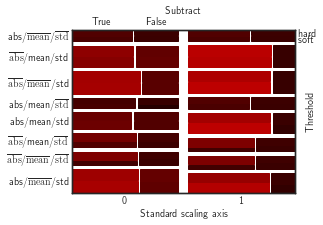

```python
sns.set_style('white')
cmapHot = plt.get_cmap('hot')

fig = plt.figure( figsize = ( 8 , 3 ))
ax1 = fig.add_axes([ 0.05 , 0.80 , 0.9 , 0.1 ])
norm = mpl.colors.Normalize(vmin=0., vmax=1.)

cb1 = mpl.colorbar.ColorbarBase(
    ax1, cmap=cmapHot, norm=norm, orientation = 'horizontal'
)
cb1.set_label('Adjusted Rand Index')
plt.show()

print 'Original signal'
custom_mosaic_wtt(mosaic_data_ari_plain, mosaic_data_3var_dict, cmapHot)
plt.show()
print '1st derivative'
custom_mosaic_wtt(mosaic_data_ari_d1, mosaic_data_3var_dict, cmapHot)
plt.show()
print '2nd derivative'
custom_mosaic_wtt(mosaic_data_ari_d2, mosaic_data_3var_dict, cmapHot)
plt.show()
```

#### 3.5 AC perfomance for different ranks

Up to section $\quad$ Return to contents

```
current config: th=soft, with_abs=0, with_mean=1, with_std=1, subtract=True, scaling axis=1
```

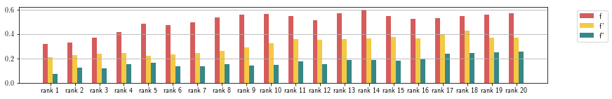

```python
use_subset = True

th = 'soft'
with_abs = False
with_mean = True
with_std = True
subtract = True
stsc_axis = 1

if use_subset:
    print 'current config: th=%s, with_abs=%d, with_mean=%d, with_std=%d, subtract=%s, scaling axis=%d' % (
        th, with_abs, with_mean, with_std, subtract, stsc_axis
    )


    ind_th = param_grid['th'].index(th)
    ind_abs = param_grid['with_abs'].index(with_abs)
    ind_mean = param_grid['with_mean'].index(with_mean)
    ind_std = param_grid['with_std'].index(with_std)
    ind_stsc = param_grid['stsc_axis'].index(stsc_axis)
    ind_sub = param_grid['subtract'].index(subtract)
ind_sc = ari_sn_i

wtt_ac_plain, axesList_plain = npz2vec3_fromDirectory(
    results_dirname, filename_base, 'plain', which='mean'
)
wtt_ac_d1, axesList_d1 = npz2vec3_fromDirectory(
    results_dirname, filename_base, 'd1', which='mean'
)
wtt_ac_d2, axesList_d2 = npz2vec3_fromDirectory(
    results_dirname, filename_base, 'd2', which='mean'
)

wtt_ac_all = np.stack([wtt_ac_plain, wtt_ac_d1, wtt_ac_d2], axis=0)
if use_subset:
    wtt_ac_all = wtt_ac_all[:, :, :, :, ind_stsc, ind_sub, :, ind_th, ind_abs, ind_mean, ind_std, ind_sc]
    wtt_ac_all = np.transpose(wtt_ac_all, [0, 1, 2, 4, 3])
    wtt_ac_all = np.reshape(wtt_ac_all, [3, Naffinity*Nlinkage*Ntau, -1])
else:
    wtt_ac_all = np.transpose(wtt_ac_all.T[ind_sc].T, [0, 1, 2, 4, 5, 6, 7, 8, 9, 10, 3])
    wtt_ac_all = np.reshape(wtt_ac_all, [3, -1, Nranks])

ind1 = np.argmax(wtt_ac_all[0], axis=0)
ind2 = np.argmax(wtt_ac_all[1], axis=0)
ind3 = np.argmax(wtt_ac_all[2], axis=0)

f, ax = plt.subplots(figsize=(1.35*10, 2))
barwidth = 0.2

ari_plain = [wtt_ac_all[0, ind1[i], i] for i in xrange(len(param_grid['rank']))]
ari_d1 = [wtt_ac_all[1, ind2[i], i] for i in xrange(len(param_grid['rank']))]
ari_d2 = [wtt_ac_all[2, ind3[i], i] for i in xrange(len(param_grid['rank']))]

b1a = ax.bar(
    param_grid['rank'], ari_plain, width=barwidth, color=barplot_palette[0], alpha=0.8
)

b1b = ax.bar(
    param_grid['rank']+barwidth, ari_d1, width=barwidth, color=barplot_palette[2], alpha=0.8
)

b1c = ax.bar(
    param_grid['rank']+2*barwidth, ari_d2, width=barwidth, color=barplot_palette[4], alpha=0.8
)


xticks = map(
    lambda x: 'rank %d' % (x), param_grid['rank']
)
ax.set_ylim(0., 0.62)


ax.set_xticks(param_grid['rank']+barwidth)
ax.set_xticklabels(xticks)
ax.legend(
    (b1a[0], b1b[0], b1c[0]),
    ('f', "f'", 'f"'),
    loc='upper right',
    bbox_to_anchor=(1.12, 1.)
)
ax.yaxis.grid(True)
plt.show()
```

Return to contents